# Data Visualization with R - Hands-On

Valentin Geier, Zoé Wolter

Jan 25, 2022

## Load required packages

First things first: We always start with loading all the relevant packages. It is quite nice to do so in a separate R-file and then call this file via `source(packages.R)`, but here you can just use the following code chunk to load the `tidyverse`:

```r
# Insert your code here!
library(tidyverse)
```

## The data

### Load the data

For this hands-on session we will have a look at the bicycle data of the city of Konstanz retrieved from their [OpenData-portal](https://offenedaten-konstanz.de) - those of you who already visited our data manipulation workshop are already familiar with this dataframe. You can find the data with the following link: https://offenedaten-konstanz.de/sites/default/files/Z%C3%A4hlstelle_Heros%C3%A9_2020_Wetter_st%C3%BCndlich.csv. Input this link in the code chunk below to load the data into R Studio:

```r
# Insert your code here!
readr::read_delim('https://offenedaten-konstanz.de/sites/default/files/Z%C3%A4hlstelle_Heros%C3%A9_2020_Wetter_st%C3%BCndlich.csv',
                  delim = ";",
                  escape_double = FALSE,
                  trim_ws = TRUE) -> bikes
```

### A first glance at the data and some data cleaning

When you retrieved the data, then you first want to have an overview of the variables, observations and so on.

Those are the variables included:

- Zeit: date (DD.MM.JJJJ) and time (HH:MM)
- Fahrradbruecke: total number of cyclists
- Fahrradbruecke stadteinwaerts: number of cyclists in the direction of the city center
- Fahrradbruecke stadtauswaerts: number of cyclists in the direction out of town
- Symbol Wetter: weather categorization
- Temperatur: measured temperature at the given time in degrees Celsius
- Gefühlte Temperatur: perceived temperature measured according to the heat index at the given time in degrees Celsius
- Regen (mm): precipitation at the time in millimeters

In order to work with the data set, we selected the following variables and give them those names:

- datetime
- num_total
- num_out
- num_in
- weather
- temp
- rain

```r
# Insert your code here!
bikes %>%
  dplyr::select(
    datetime = 'Zeit',
    num_total = 'FahrradbrueckeFahrradbruecke',
    num_in = 'FahrradbrueckeFahrradbruecke stadteinwärts Fahrräder',
    num_out = 'FahrradbrueckeFahrradbruecke stadtauswärts Fahrräder',
    weather = 'Symbol Wetter',
    temp = 'Temperatur (°C)',
    rain = 'Regen (mm)'
  ) -> bikes
```

Now we need to check the data type of the variables and probably change them - since this is no data cleaning workshop, we’ve already done this task for you here:

```r
bikes$datetime %>%
  lubridate::dmy_hm() -> bikes$datetime
bikes %>%
  dplyr::mutate(
    day = as.Date(datetime),
    time = format(as.POSIXct(datetime), format = "%H:%M:%S"),
    .keep = 'unused'
  ) -> bikes
bikes$weather %>%
  as.factor() -> bikes$weather
```

Next we want a data frame `bikes_days` which summarizes the number of bikes, temperature and so on per day. Again, we’ve already done this task for you:

```r
bikes %>%
  dplyr::group_by(day) %>%
  dplyr::summarize(num_total = sum(num_total, na.rm = TRUE),
                   num_in = sum(num_in, na.rm = TRUE),
                   num_out = sum(num_out, na.rm = TRUE),
                   temp = mean(temp, na.rm = TRUE),
                   rain = sum(rain, na.rm = TRUE)) -> bikes_days
```

## Data Viz

And finally: the fun part - data visualizations!

### Line plot

First, we start with a simple **line plot**: How many bikes are passing the bike bridge in Konstanz per day? Please:

- display smoothed conditional means
- use a minimal theme
- name the x axis and y axis appropriately
- add a title and a subtitle, as well as a caption with the source of the data

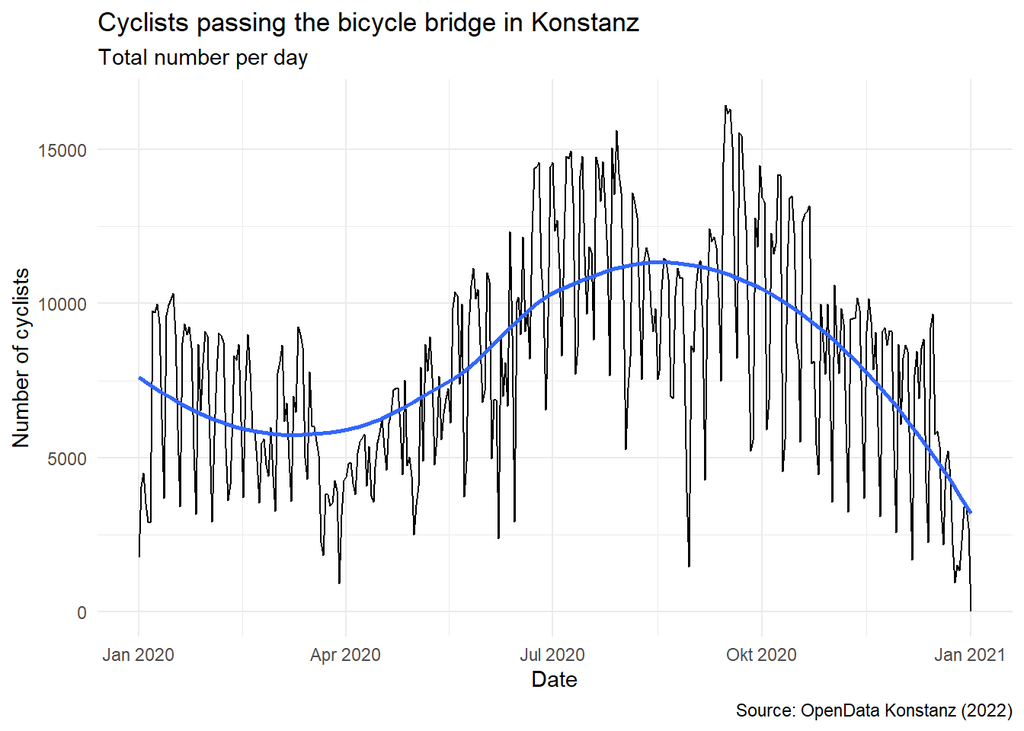

```r
# Insert your code here!
bikes_days %>%
  ggplot2::ggplot(mapping = aes(x = day,
                                y = num_total)) +
  geom_line() +
  geom_smooth(se = FALSE) +
  theme_minimal() +
  labs(x = "Date",
       y = "Number of cyclists",
       title = "Cyclists passing the bicycle bridge in Konstanz",
       subtitle = "Total number per day",
       caption = "Source: OpenData Konstanz (2022)")
```

### Scatter plot

Kind of obvious, but is there a perfect correlation between bikes going out of town and bikes going in the direction of the city center? Use a **scatterplot** to visualize this super interesting question! Please:

- use a minimal theme
- name the x axis and y axis appropriately
- add a title and a subtitle, as well as a caption with the source of the data (Hint: if your (sub-)title is too long, you can use `\n` in your string to start a new line)
- *EXTRA*: color the points according to whether it had more than 15°C on average on this day, change colors to blue (<=15°C) and red (>15°C) and change legend title and labels

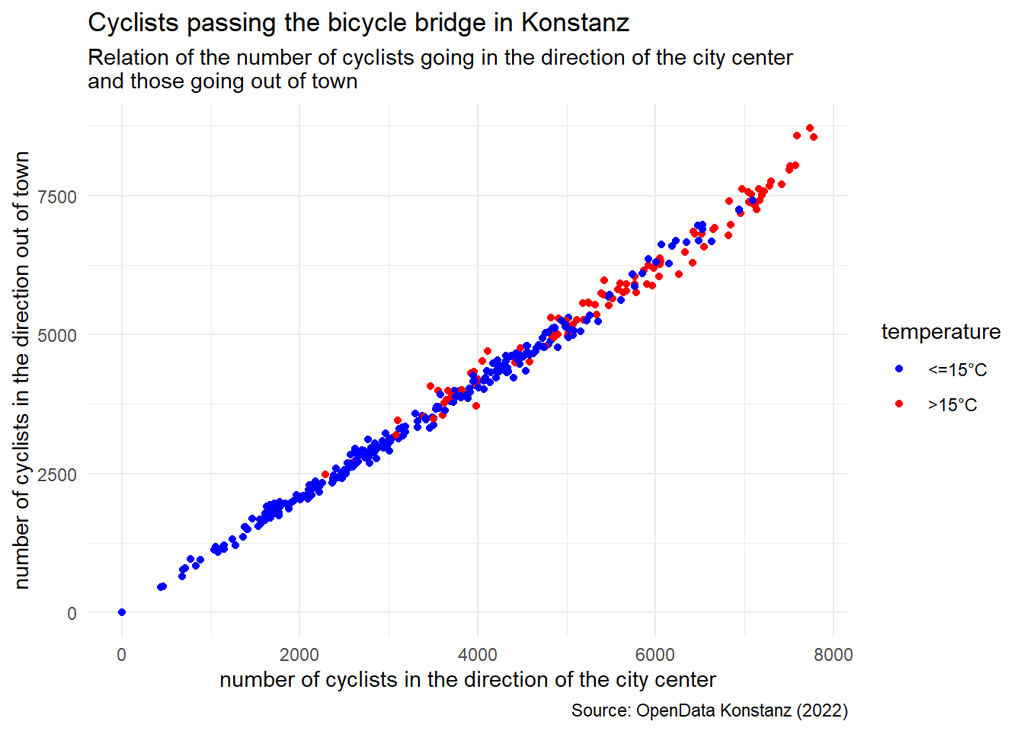

```r
# Insert your code here!
bikes_days %>%
  dplyr::mutate(
    temp_high = factor(ifelse(temp > 15, 1, 0))
  ) %>%
  ggplot(mapping = aes(x = num_in,
                       y = num_out,
                       col = temp_high)) +
  geom_point() +
  theme_minimal() +
  scale_color_manual(values = c('blue', 'red'), labels = c('<=15°C', '>15°C')) +
  labs(x = "number of cyclists in the direction of the city center",
       y = "number of cyclists in the direction out of town",
       title = "Cyclists passing the bicycle bridge in Konstanz",
       subtitle = "Relation of the number of cyclists going in the direction of the city center\nand those going out of town",
       caption = "Source: OpenData Konstanz (2022)",
       color = 'temperature')
```

### Bar plot

Second, we want to know which is the month with most of rain at the bike bridge in Konstanz. Use a **bar plot** to find out! Remember that in our data frame rows correspond to days, but here we want to have months. Please:

- use a minimal theme
- name the x axis and y axis appropriately
- add a title and a subtitle, as well as a caption with the source of the data
- change the color of the bars to `blue`
- change the displayed x label ticks to the name of the months and rotate them

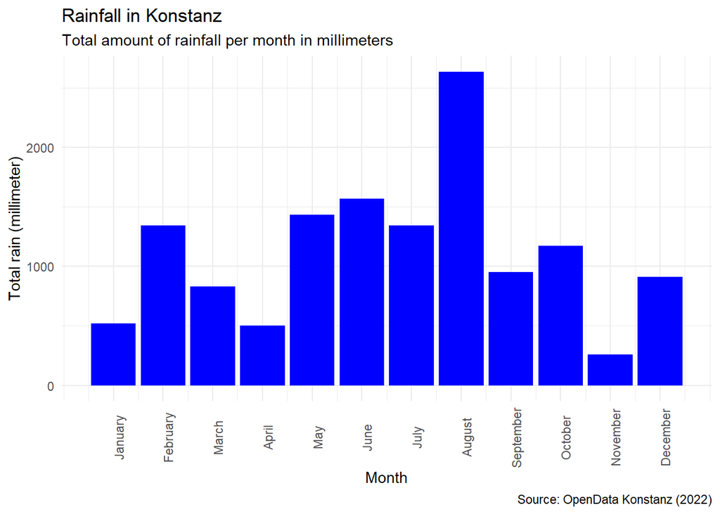

```r
# Insert your code here!
# data cleaning and preprocessing
bikes_days %>%
  dplyr::mutate(
    year = lubridate::year(day),
    month = lubridate::month(day),
    day = lubridate::day(day),
    .keep = 'unused'
  ) %>%
  dplyr::group_by(month) %>%
  dplyr::summarize(num_total = sum(num_total, na.rm = TRUE),
                   num_in = sum(num_in, na.rm = TRUE),
                   num_out = sum(num_out, na.rm = TRUE),
                   temp = mean(temp, na.rm = TRUE),
                   rain = sum(rain, na.rm = TRUE)) %>%

  # actual plotting of the data
  ggplot2::ggplot(mapping = aes(x = month,
                                y = rain)) +
  geom_col(fill = 'blue')  +
  theme_minimal() +
  scale_x_continuous(breaks = c(1:12),
                     labels = c('January',
                                'February',
                                'March',
                                'April',
                                'May',
                                'June',
                                'July',
                                'August',
                                'September',
                                'October',
                                'November',
                                'December')) +
  theme(axis.text.x = element_text(angle = 90)) +
  labs(x = "Month",
       y = "Total rain (millimeter)",
       title = "Rainfall in Konstanz",
       subtitle = "Total amount of rainfall per month in millimeters",
       caption = "Source: OpenData Konstanz (2022)")
```

**WELL DONE!**